# Ice and snow analysis

```r
library(dplyr)
library(tidyverse)
library(here)
library(lme4)
```

This notebook looks at whether dictionaries for languages in cold locations tend to include more occurrences of words related to “ice” and “snow”. First we load dictionary counts and information about the temperature associated with each dictionary.

```r
wordcount_path<- here("data", "wordcount.csv")  # this file incorporates pre-processing steps used in the BILA paper -- ie stop words have already been removed

dict_path <- here("data", "bila_dictionaries_withenv.csv")

wordcount <- read_csv(wordcount_path)
dict <- read_csv(dict_path)
```

Gather counts for relevant terms. We’ll consider three groups of words: `snow_group` includes words related to snow, `ice_group` includes words related to ice, and `snowice_group` combines words from both of the first two groups.

```r
snow_group <- c("snow", "snowball", "snowstorm", "snowfall", "snowflake", "blizzard", "snowdrift", "snowfield", "sleet")
ice_group <- c("ice", "frost", "glacier", "iceberg")
snowice_group <- c(snow_group, ice_group)

cwd <- tibble(groups=list(
  tibble(group="snow_group", word=snow_group),
  tibble(group="ice_group", word=ice_group),
  tibble(group="snowice_group", word=snowice_group)
  ))

wordgroups <- unnest(cwd, groups)

all_words <- wordgroups$word
all_groups <- unique(wordgroups$group)
singlewords <-  str_subset(all_groups, "_group", negate=TRUE)

all_regex <-  paste0("^(", paste(all_words, collapse="|"), ")$")

cases_wordcount <- wordcount %>%
  select(id, matches(all_regex), dictsize_data)

cases_wordcount_long <- cases_wordcount %>%
  pivot_longer(cols = -c(id, dictsize_data), names_to = "word", values_to = "count") %>%
  right_join(wordgroups, by = "word")

cases_wordcount_grouped_long <- cases_wordcount_long %>%
  group_by(id, dictsize_data, group) %>%
  summarize(
    count = case_when(
      any(!is.na(count)) ~ sum(count, na.rm = TRUE),
      TRUE ~ NA_real_
    ), .groups = "drop"
  ) %>%
  ungroup()

# take out dictionaries where wiktionary filter was applied. For example, Wiktionary indicates that "ice" is an inflection of a Portuguese verb meaning "to raise", so we don't want to include "ice" in the counts for Portuguese dictionaries.

filtered_combos <- read_csv(here("data", "wiktionary_filtered_combinations.csv"), show_col_types = FALSE) %>%
  filter(word %in% all_words) %>%
  left_join(wordgroups %>% unique(), by="word") %>%
  select(glottocode, group) %>%
  unique()

cases_wordcount <- cases_wordcount_grouped_long %>%
  left_join(dict %>% select(id, glottocode), by="id") %>%
  anti_join(filtered_combos, by=c("glottocode", "group")) %>%
  select(-glottocode) %>%
  pivot_wider(names_from = group, values_from = count)

# we'll express frequencies in terms of counts per 10000 tokens
countunit <- 10000

cases_wordcount_raw <- cases_wordcount %>%
  select(id, ice_group, snow_group, snowice_group) %>%
  rename(ice_group_raw = ice_group, snow_group_raw = snow_group, snowice_group_raw = snowice_group)

# d is the dataframe we'll use for our analyses
d <- cases_wordcount %>%
  mutate(across(-c(id, dictsize_data), ~(.x * countunit/dictsize_data))) %>%
  mutate(countunit= countunit) %>%
  left_join(cases_wordcount_raw, by = "id") %>%
  inner_join(dict, by="id")
```

## Exploratory plot

Plot the relationship between combined frequency for the three groups (“snow”, “ice”, “ice and snow”) and temperature.

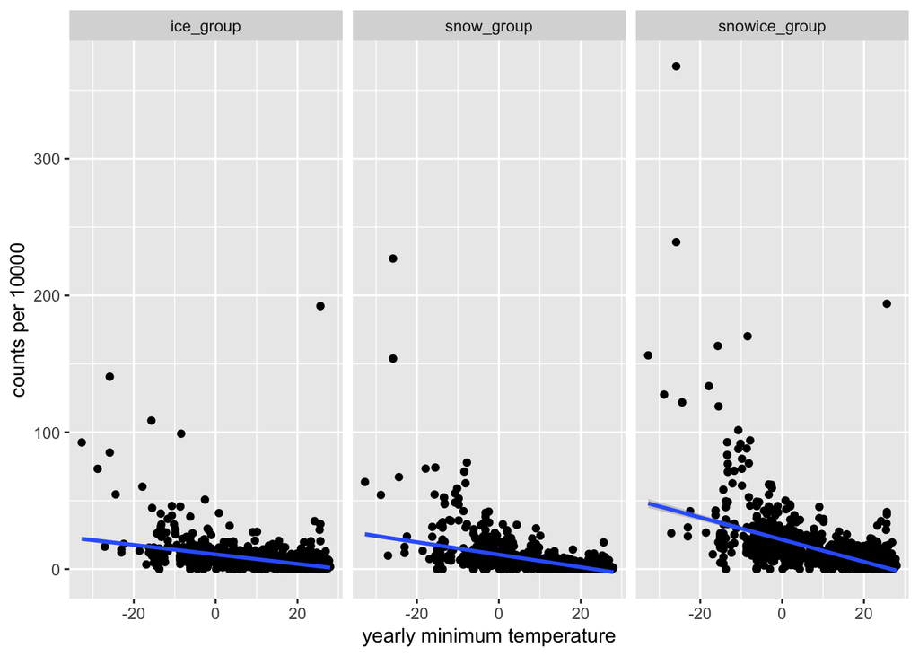

```r
# convert to long form for easy plotting
plotd <- d %>%
  pivot_longer(cols=matches(c("snow_group$", "ice_group$", "snowice_group$")), names_to="word", values_to="propn")

propnplot <- plotd %>%
  ggplot(aes(x=minmonth_tmp, y=propn)) +
  geom_point() +
  facet_wrap(~word) +
  geom_smooth(method=lm) +
  labs(y="counts per 10000", x="yearly minimum temperature")

show(propnplot)
```

The plot suggests that dictionaries for languages from cold regions do tend to include more tokens of words related to “ice” and “snow.”

## Statistical analysis

The analysis here uses mixed effects models. Please see Bodo Winter’s two part tutorial (posted on Canvas) for an introduction to the general approach. Following the Winter tutorial we’ll take a frequentist approach here – if you’d like to run Bayesian analyses at some stage you could try the `brms` package.

We’ll use binomial models because the dependent variable is a proportion (counts for ice and snow out of a total of `dictsize` counts for an entire dictionary).

We’ll include a random effect for language to capture the idea that dictionaries for the same language are expected to have similar proportions, and a random effect for language family to capture historical relationships between languages.

```r
# m1 is a "full model" that includes the environment variable as a predictor

m1 <- glmer(cbind(snowice_group_raw, dictsize_data - snowice_group_raw) ~ minmonth_tmp + (1|langfamily) + (1|langfamily:glottocode), data = d, family = binomial, control=glmerControl(optimizer="bobyqa"))

# pull out regression coefficient for temperature

beta_temp <- round(coef(summary(m1))[2,"Estimate"], 2)

show(m1)
```

```
## Generalized linear mixed model fit by maximum likelihood (Laplace
##   Approximation) [glmerMod]
##  Family: binomial  ( logit )
## Formula: cbind(snowice_group_raw, dictsize_data - snowice_group_raw) ~
##     minmonth_tmp + (1 | langfamily) + (1 | langfamily:glottocode)
##    Data: d
##       AIC       BIC    logLik -2*log(L)  df.resid
## 15754.642 15775.573 -7873.321 15746.642      1380
## Random effects:
##  Groups                Name        Std.Dev.
##  langfamily:glottocode (Intercept) 0.7055
##  langfamily            (Intercept) 0.4262
## Number of obs: 1384, groups:  langfamily:glottocode, 603; langfamily, 83
## Fixed Effects:
##  (Intercept)  minmonth_tmp
##     -6.46663      -0.06825
```

The negative coefficient for `minmonth_tmp` indicates that increases in temperature tend to be associated with decreases in count proportions of “ice” and “snow”. The magnitude of the coefficient indicates that increasing temperature by 1 degree reduces the log odds of the count proportion by around 0.07.

Now we run a “reduced” model that doesn’t include `minmonth_tmp` as a predictor:

```r
m2 <- glmer(cbind(snowice_group_raw, dictsize_data - snowice_group_raw) ~ (1|langfamily) + (1|langfamily:glottocode), data = d, family = binomial, control=glmerControl(optimizer="bobyqa"))
```

Now we compare the full and reduced models using a likelihood ratio test to see if including the environment variable produces a significant improvement.

```r
a <- anova(m2, m1)

# pull out p value and chi-squared statistic
p_value <-  signif(a$"Pr(>Chisq)"[2] , digits=3)
chi_sq <- signif(a$Chisq[2], digits=3)
df <- a$Df[2]

show(a)
```

```
## Data: d
## Models:
## m2: cbind(snowice_group_raw, dictsize_data - snowice_group_raw) ~ (1 | langfamily) + (1 | langfamily:glottocode)
## m1: cbind(snowice_group_raw, dictsize_data - snowice_group_raw) ~ minmonth_tmp + (1 | langfamily) + (1 | langfamily:glottocode)
##    npar   AIC   BIC  logLik -2*log(L)  Chisq Df Pr(>Chisq)
## m2    3 15928 15943 -7960.8     15922
## m1    4 15755 15776 -7873.3     15747 174.95  1  < 2.2e-16 ***
## ---
## Signif. codes:  0 '***' 0.001 '**' 0.01 '*' 0.05 '.' 0.1 ' ' 1
```

The output indicates that there is a statistically significant relationship between `minmonth_tmp` and count proportions for “ice” and “snow” (p-value is around 6.15^{-40} ).

Following Winter’s example, here’s how you might write this up

- “We used R (R Core Team, 2012) and lme4 (Bates, Maechler & Bolker, 2012) to perform a logistic mixed effects analysis of the relationship between temperature and the combined count proportion for”ice” and “snow”. Because there were multiple dictionaries for some languages, we included a random effect for language. To allow for historical relationships between languages, we also included a random effect for language family. The analysis revealed a statistically significant relationship between temperature and count proportion of “ice” and “snow” ($\beta$ = -0.07 , $\chi^2$(1) = 175, p = 6.15^{-40}, where the p-value is based on a likelihood ratio test comparing the full model with temperature as a fixed effect to a reduced model without temperature. The coefficient for temperature indicates that increasing temperature by 1 degree reduces the log odds of the combined count proportion by around 0.07.

## Confidence intervals

It’s a good idea to report a confidence interval associated with the coefficient of interest (here temperature). This confidence interval can be computed using the `confint` function.

```r
ci <- confint(m1)
```

So the 95% confidence interval for the coefficient on temperature is [ -0.08, -0.06].